# GEN Z, sin miedo a invertir

Miguel Lerdo de Tejada, Anahí Plascencia, Alejandro Gómez, Alejandro Ortiz

2021-05-29

# El COVID-19 ha sido un impulso para que los más jóvenes inviertan

La generación Z ha demostrado que nunca es demasiado pronto para empezar a invertir, desde que comenzó la pandemia en marzo de 2020 muchos jóvenes al rededor del mundo han decidido tomar las riendas de sus finanzas personales. Muchos quizá por aburrimiento, y otros por la frustración de lo que está pasando con la economía mundial han decidido intentarlo y los resultados han sido bastante interesantes.

La facilidad con la que uno puede comprar acciones con un simple swipe a la izquierda es fascinante. El mundo digital ha venido a revolucionar los mercados y la Gen Z no perderá ninguna oportunidad para hacerlo desde casa.

Por esta razón hemos decidido analizar los efectos del lockdown en Estados Unidos para descubrir si existe un efecto causal en la tendencia de búsqueda de palabras relacionadas al mercado accionario utilizando Google Trends. Buscamos probar que debido a los confinamientos el número de búsquedas relacionadas con inversiones han aumentado.

Los resultados que obtuvimos se estimaron a través del método de Diferencias en Diferencias *(DiD)* que compara las búsquedas relacionadas con finanzas en el 2020 antes y después de los lockdowns con las búsquedas en las mismas fechas en el 2019. Los datos que se tomaron fueron para los 50 estados de Estados Unidos (más Washington DC) y la selección de palabras de términos de búsqueda relacionadas a la categoría de finanzas en Google Trends fueron las siguientes: Stock, Stocks, Market, NYSE (Se refiere a la bolsa de valores de Nueva York), Finance, Finances, Dow, NASDAQ, Business, Rate, Rates y S&P (Índice del desempeño de las 500 compaías más grandes de EEUU). Los datos de búsqueda por cada término se registraron diariamente para cada estado en ambos periodos de tiempo.

Para obtener las tendencias de búsqueda diarias entre el 1 de enero de 2019 y el 10 de abril de 2020, descargamos los datos diarios entre el 1 de enero y el 10 de abril, tanto en 2019 como en 2020. Como los datos diarios en 2019 provienen de una solicitud separada a los datos diarios en 2020, los factores de escala utilizados para calcular la puntuación de 0 a 100 no son los mismos en los dos periodos. Por lo tanto, cambiamos la escala de las dos series para que sean comparables.

Para estos casos se suele hacer un análisis llamado *ceteris paribus*. Lo que significa es que aislamos el efecto de cualquier otra variable que se nos ocurra (por ejemplo, en este caso quitamos el efecto de que a lo mejor los viernes se googlea más sobre finanzas que los domingos) para enfocarnos sólamente en la relación que nos interesa (para nosotros, el efecto del lockdown).

En primer lugar, utilizamos un modelo DiD (Diferencias en Diferencias). Nos muestra el impacto diferenciado para las búsquedas realizadas despúes de que se anunció el lockdown contra las búsquedas antes. En este caso, nos permite inferir el efecto causal del lockdown en las búsquedas.

A continuación presentamos los efectos. **Toda estimación estadística está sujeta a errores**. El impacto puntual estimado del lockdown en las búsquedas es el punto azul, y su valor está al lado de la lleyenda de $\hat{\beta}$. La línea negra muestra el error del que hablamos. Si la línea negra llega a tocar a la línea que pasa por el cero, decimos que el efecto no fue significativo. Es decir, el error de la estimación es tan grande que el número que presentamos seguramente está muy pegado al cero. El primer coeficiente de todas las gráficas es el efecto causal en las búsquedas de la palabra en cuestión. el otro coeficiente es el efecto de las muertes por COVID del día anterior.

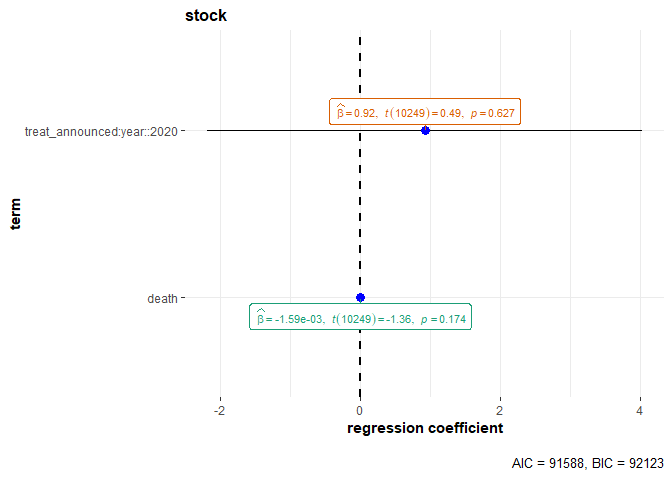

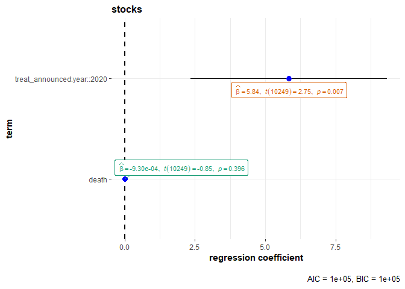

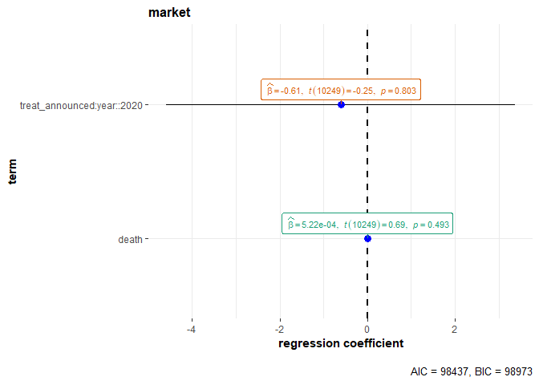

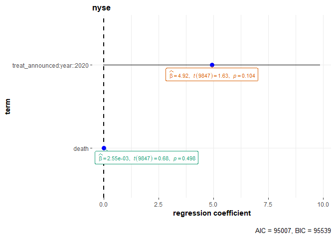

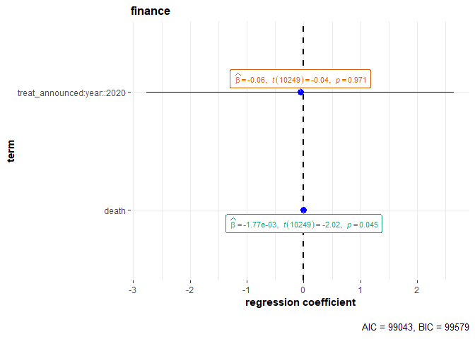

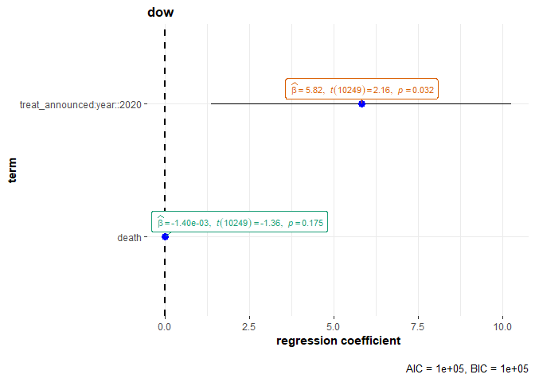

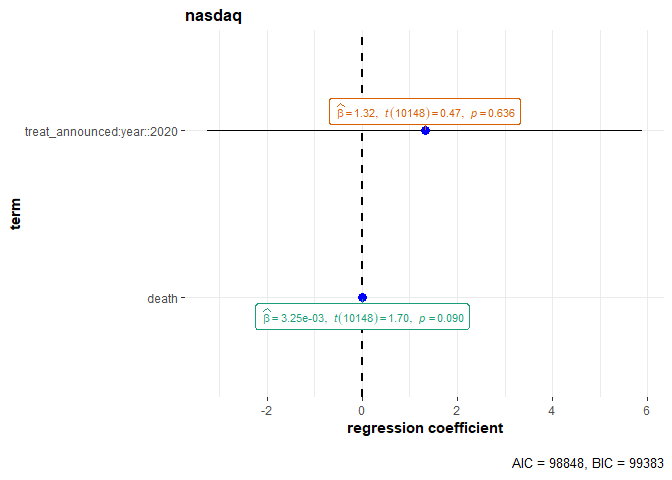

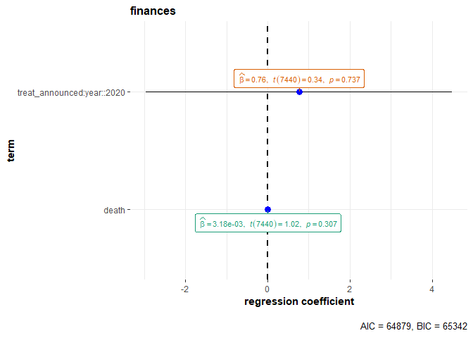

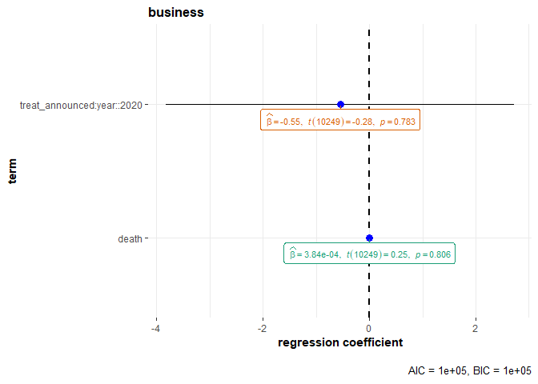

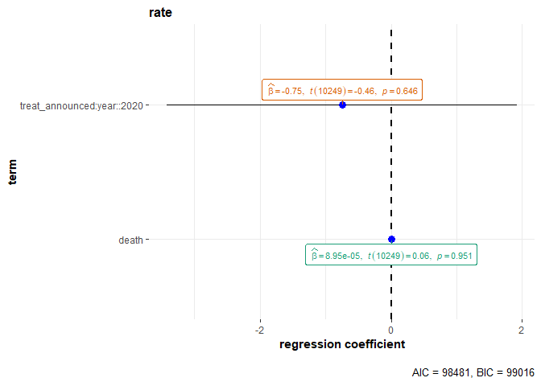

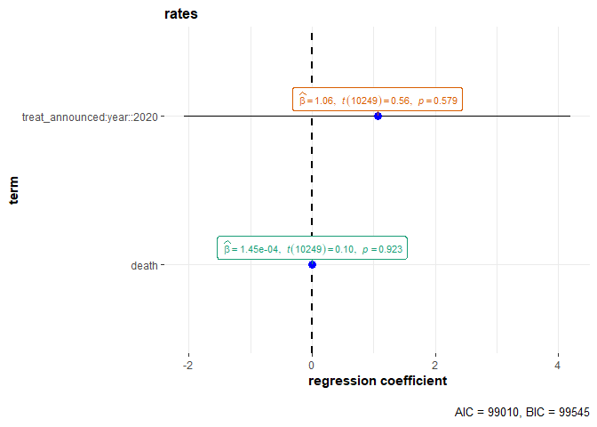

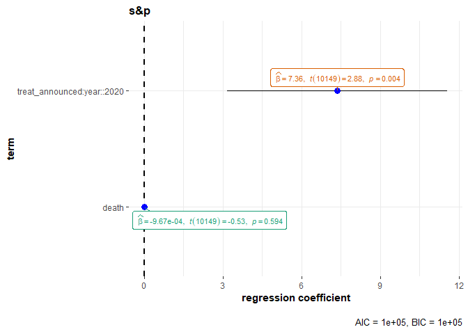

Para nuestro modelo con la palabra *“stock”* podemos concluir que el confinamiento, *ceteris paribus*, aumentó en promedio 0.92 puntos el nivel de busquedas para esta palabra.

Para el modelo con la palabra *“stocks”* el cambio causado por el confimaniento sí fue más significativo. *Ceteris paribus*, el hecho de estar en confimaniento está relacionado con un aumento en 5.8 puntos en promedio del nivel de búsquedas realizadas en Google Trends. Cabe resaltar que fue la segunda palabra con mayor aumento en nuestros modelos.

En en modelo que considera la palabra *“market”* se observa una caída en el nivel de búsquedas, y el resutado es el siguiente: *Ceteris paribus*, el hecho de estar en confinamiento causó una disminución en promedio de 0.61 puntos en el nivel de búsquedas realizadas en Google Trends. La caída promedio no fue muy grande en las búsquedas, casi podríamos considerar que se quedó constante.

En el modelo que consideró a la palabra *“finace”* tambíen reportó una disminución en el nivel de búsquedas. En este caso, *ceteris paribus*, el hecho de entrar en confinamiento está relacionado con una disminución en promedio de 0.06 puntos en el nivel de búsquedas de Google Trends. Es una disminución mínima, por lo que podemos considerar que no es significativa.

En el modelo que consideró a la palabra *“business”* tambíen reportó una disminución en el nivel de búsquedas. En este caso, *ceteris paribus*, el hecho de entrar en confinamiento está relacionado con una disminución en promedio de 0.55 puntos en el nivel de búsquedas de Google Trends. Es una disminución mínima, por lo que podemos considerar que no es significativa.

De igual forma el modelo que consideró la palabra *“rate”* muestra una caída en el nivel de búsquedas. En este caso, *ceteris paribus*, el hecho de entrar en confinamiento está relacionado con una disminución en promedio de 0.75 puntos en el nivel de búsquedas de Google Trends. De igual forma es una disminución poco considerable.

Sin embargo, el modelo para la palabra *“rates”* sí reporta un pequeño aumento. *Ceteris paribus*, el hecho de entrar en confinamiento, está relacionado con un aumento de 1.1 puntos en el nivel de búsquedas promedio de esta palabra en Google Trends.

Por último, esta el modelo para la palabra *“S&P”* que reporta el mayor incremento de todos los demás modelos. En este caso se reportó que *ceteris paribus*, el hecho de entrar en confinamiento está relacionado con un aumento de 7.4 puntos en el nivel promedio de búsquedas de estas palabras.

### Resultados Regresión Discontinua

Un análisis más puntual es el de regresión discontinua. Nos dice si el efecto del lockdown causó que las tendencias cambiaran **el mismo día que se anunció el lockdown**.

Para estimar la regresión discontinua tomamos en cuenta la fecha de corte como el inicio del lockdown y así poder ver si hubo un efecto inmediato o no en las búsquedas relacionadas con finanzas.

Para el año 2020:

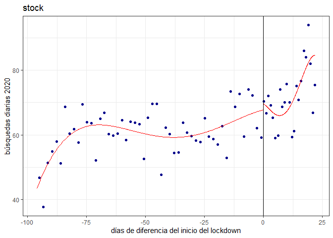

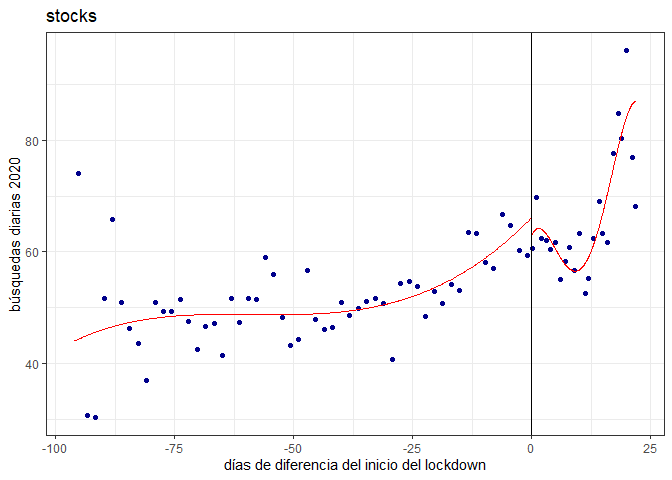

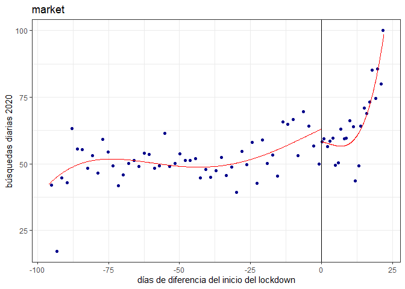

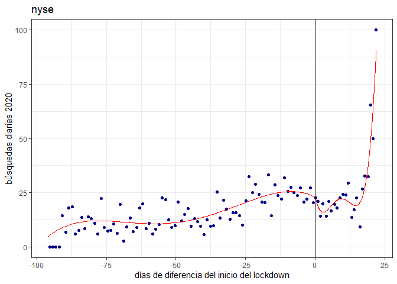

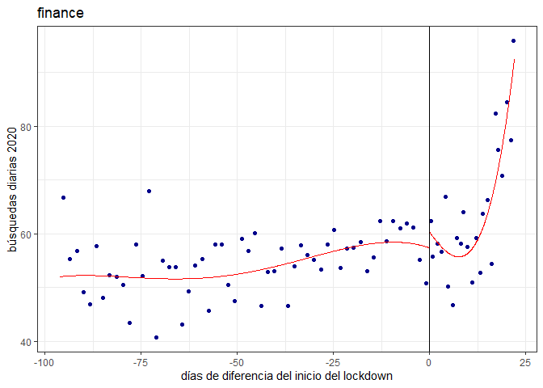

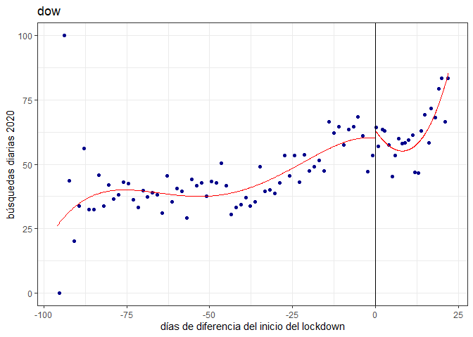

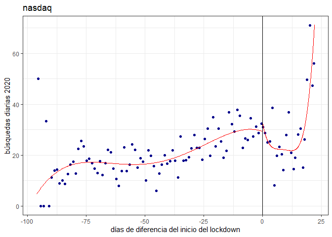

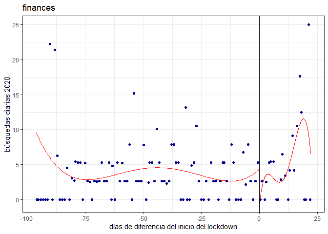

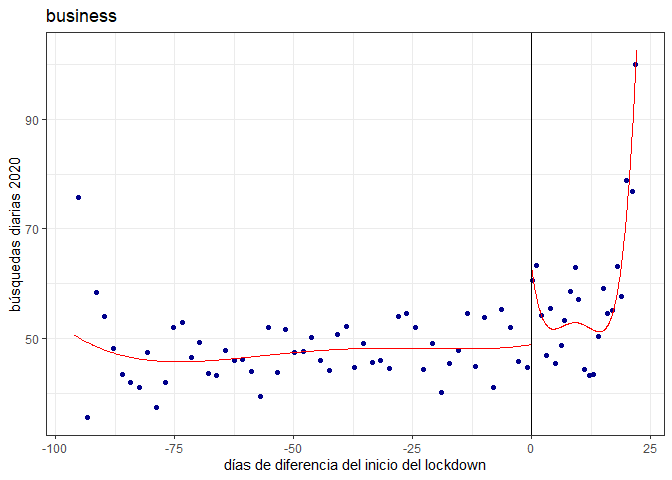

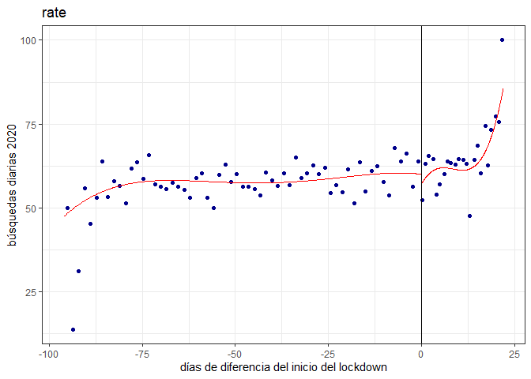

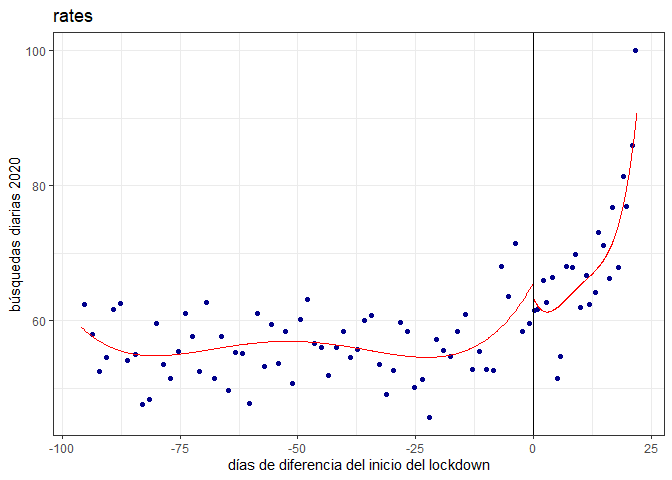

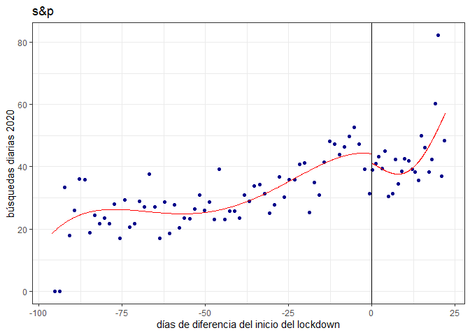

Para el año 2019:

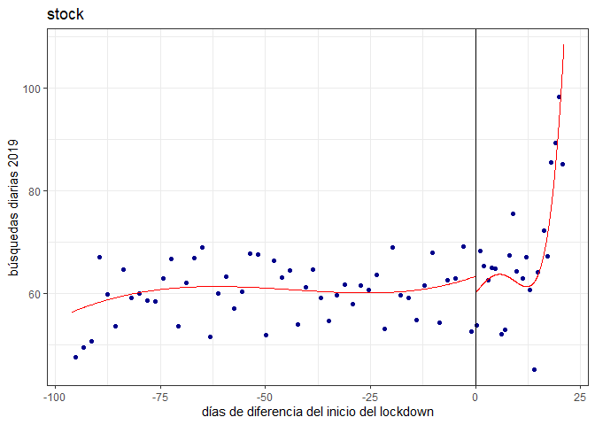

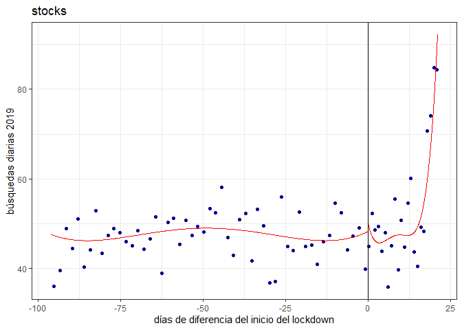

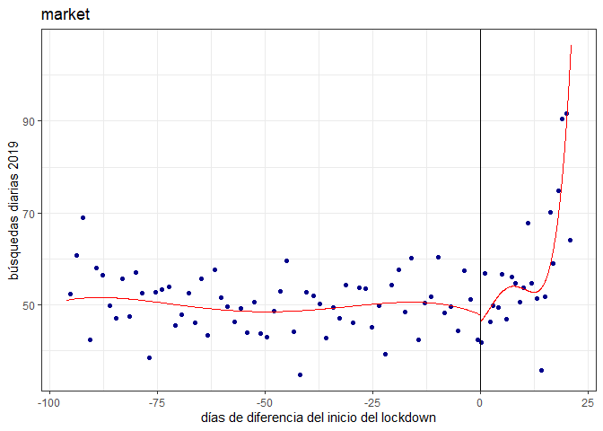

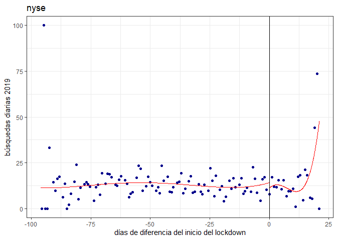